# Coffee Sales Overtime

Terence Morita

2025-01-04

## Introduction

The objective of this analysis is to determine coffee flavour popularity, and its relation to the time of the year. With this information, a story could be made on whether adjusting the prices of certain flavours during given months could result in greater profits. Also, insights gained could be used to future proof inventory stocking. The data set contains data between March 2024 and December 2024 inclusive. As more data is available, this analysis will be rerun. The analysis works with an [open source dataset](https://www.kaggle.com/datasets/ihelon/coffee-sales/data) from Kaggle, by Yaroslav Isaikenkov.

## Cleaning Data

To ensure data is clean to work with, I checked for duplicates, missing or invalid values, and misspellings.*Note that card column should be empty if payment method is cash*

```r
## View quick summary on data

summary(data)
```

```
##       date               datetime                       cash_type
##  Min.   :2024-03-01   Min.   :2024-03-01 10:15:50.51   Length:2623
##  1st Qu.:2024-05-31   1st Qu.:2024-05-31 08:37:32.54   Class :character
##  Median :2024-08-17   Median :2024-08-17 21:18:56.80   Mode  :character
##  Mean   :2024-08-08   Mean   :2024-08-09 12:21:54.03
##  3rd Qu.:2024-10-17   3rd Qu.:2024-10-17 08:41:16.96
##  Max.   :2024-12-23   Max.   :2024-12-23 20:46:07.23
##      card               money       coffee_name
##  Length:2623        Min.   :18.12   Length:2623
##  Class :character   1st Qu.:27.92   Class :character
##  Mode  :character   Median :32.82   Mode  :character
##                     Mean   :31.89
##                     3rd Qu.:35.76
##                     Max.   :40.00
```

```r
str(data)
```

```
## spc_tbl_ [2,623 × 6] (S3: spec_tbl_df/tbl_df/tbl/data.frame)
##  $ date       : Date[1:2623], format: "2024-03-01" "2024-03-01" ...
##  $ datetime   : POSIXct[1:2623], format: "2024-03-01 10:15:50" "2024-03-01 12:19:22" ...
##  $ cash_type  : chr [1:2623] "card" "card" "card" "card" ...
##  $ card       : chr [1:2623] "ANON-0000-0000-0001" "ANON-0000-0000-0002" "ANON-0000-0000-0002" "ANON-0000-0000-0003" ...
##  $ money      : num [1:2623] 38.7 38.7 38.7 28.9 38.7 33.8 38.7 33.8 38.7 33.8 ...
##  $ coffee_name: chr [1:2623] "Latte" "Hot Chocolate" "Hot Chocolate" "Americano" ...
##  - attr(*, "spec")=
##   .. cols(
##   ..   date = col_date(format = ""),
##   ..   datetime = col_datetime(format = ""),
##   ..   cash_type = col_character(),
##   ..   card = col_character(),
##   ..   money = col_double(),
##   ..   coffee_name = col_character()
##   .. )
##  - attr(*, "problems")=<externalptr>
```

```r
## Ensure there are no misspelled coffee names
unique(data$coffee_name)
```

```
## [1] "Latte"               "Hot Chocolate"       "Americano"
## [4] "Americano with Milk" "Cocoa"               "Cortado"
## [7] "Espresso"            "Cappuccino"
```

```r
## Check for unusual coffee prices
unique(data$money)
```

```
##  [1] 38.70 28.90 33.80 40.00 24.00 35.00 30.00 25.00 32.82 39.00 37.72 27.92
## [13] 29.00 34.00 23.02 18.12 35.76 30.86 25.96 21.06
```

```r
## Remove duplicate data
clean_data <- data %>% distinct()

## Remove data with empty entries, with the exception of "card" when "cash_type" == "cash".

clean_data <- clean_data %>%
  filter(
    !(is.na(card) & cash_type != "cash") &
    !if_any(everything(), is.na)
  )
```

## Price Changes Over the Year

Price is an important factor customers consider when making purchases. Running the code below will provide a visualization of the price changes over the year for each coffee flavour. We find that every flavour undergoes the same transformation of price change over the year. As a result, we now know the prices of the flavours are normalized throughout the year.

```r
# Convert date time column
clean_data <- clean_data %>%
  mutate(month = month(date, label = TRUE, abbr = TRUE))



# Calculate the average price for each coffee flavour by month
price_data <- clean_data %>%
  group_by(month, coffee_name) %>%
  summarise(avg_price = mean(money, na.rm = TRUE)) %>%
  arrange(match(month, c("Mar", "Apr", "May", "Jun", "Jul", "Aug", "Sep", "Oct", "Nov","Dec")))
```

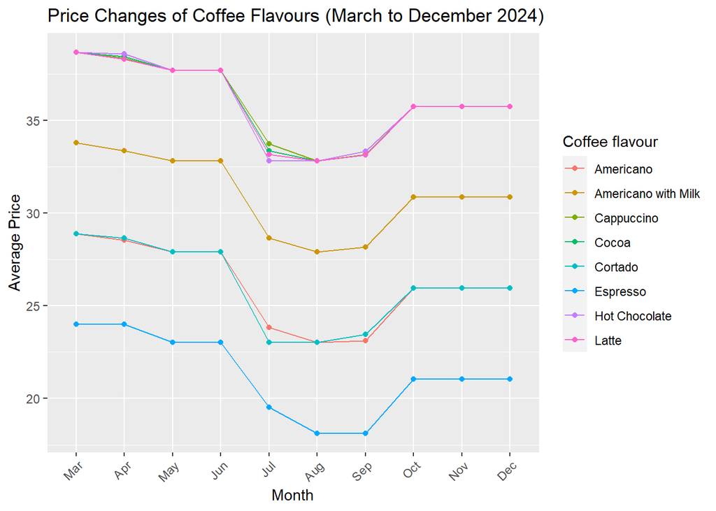

```r
# Create the plot
price_plot <- ggplot(price_data, aes(x = month, y = avg_price, color = coffee_name, group = coffee_name)) +
  geom_line() +
  geom_point() +
  labs(title = "Price Changes of Coffee Flavours (March to December 2024)",
       x = "Month",
       y = "Average Price",
       color = "Coffee flavour") +
  theme(axis.text.x = element_text(angle = 45, hjust = 1))

print(price_plot)
```

## Number of Sales made per Month, plus Revenue per Month

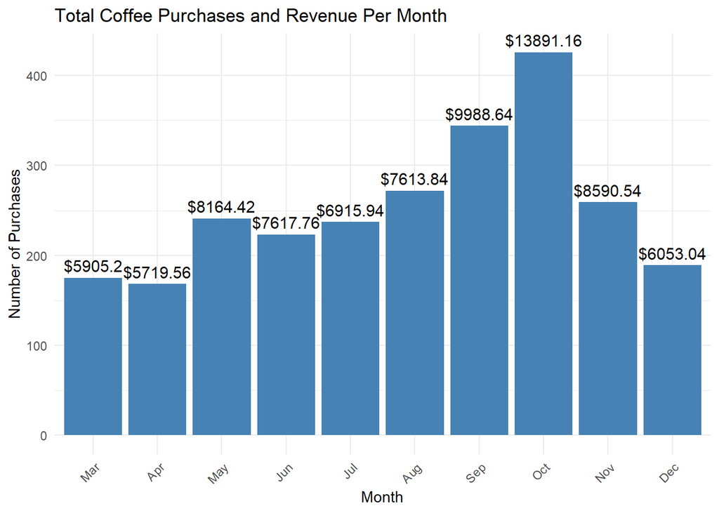

```r
# Summarize total purchases and revenue for each month
monthly_totals <- clean_data %>%
  group_by(month) %>%
  summarise(
    total_purchases = n(),
    total_revenue = sum(money),
    .groups = "drop"
  ) %>%
  mutate(month = factor(month, levels = months_visual)) %>%
  arrange(month)

# Create the bar plot with revenue labels
total_purchases_bar_plot <- ggplot(monthly_totals, aes(x = month, y = total_purchases)) +
  geom_bar(stat = "identity", fill = "steelblue") +
  geom_text(
    aes(label = paste0("$", round(total_revenue, 2))),
    vjust = -0.5,
    color = "black",
    size = 4
  ) +
  labs(
    title = "Total Coffee Purchases and Revenue Per Month",
    x = "Month",
    y = "Number of Purchases"
  ) +
  theme_minimal() +
  theme(
    axis.text.x = element_text(angle = 45, hjust = 1)
  )

print(total_purchases_bar_plot)
```

## Complete Visualiation for Coffee Flavour Popularity

**The following is the most informative visual for coffee flavour popularity over the course of a year**

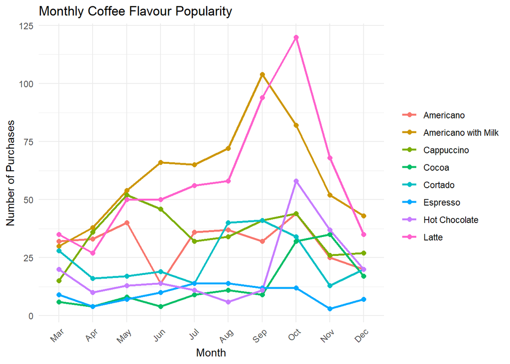

```r
# Summarize data across all months
coffee_trends <- clean_data %>%
  group_by(month, coffee_name) %>%
  summarise(purchase_count = n(), .groups = "drop") %>%
  arrange(factor(month, levels = months_visual)) %>%
  mutate(month = factor(month, levels = months_visual))

# Create the line plot
line_plot <- ggplot(coffee_trends, aes(x = month, y = purchase_count, color = coffee_name, group = coffee_name)) +
  geom_line(size = 1) +
  geom_point(size = 2) +
  labs(
    title = "Monthly Coffee Flavour Popularity",
    x = "Month",
    y = "Number of Purchases",
    color = "Coffee Flavour"
  ) +
  theme_minimal() +
  theme(
    axis.text.x = element_text(angle = 45, hjust = 1),
    legend.title = element_blank()
  )
print(line_plot)
```

## Recommendations

### Potential Price Adjustments for Specific Flavours Based on Demand

We could see that initially the flavours are relatively close in popularity. However as time progresses, we could see the drastic difference in the popularity of the flavours.

For instance, the most obvious is that both Americano with Milk and Latte are by far the most bought flavours during summer and fall.

Seeing that the Latte costs more than Americano with milk, it could be beneficial to raise the price of the cheaper flavour to match the more expensive one, and then collect more data to observe its result.